# Risk Factor Analysis

## Outcome Variable

**Outcome Variable:** whz

## Predictor Variables

**Intervention Variable:** nhh

**Adjustment Set:**

- arm
- W_mage
- meducyrs
- feducyrs
- hhwealth_quart
- W_mhtcm
- W_mwtkg
- W_mbmi
- W_nrooms
- cleanck
- impfloor
- impsan
- safeh20
- delta_W_mage
- delta_meducyrs
- delta_feducyrs
- delta_hhwealth_quart
- delta_W_mhtcm
- delta_W_mwtkg
- delta_W_mbmi
- delta_W_nrooms
- delta_cleanck
- delta_impfloor
- delta_impsan
- delta_safeh20

## Stratifying Variables

The analysis was stratified on these variable(s):

- agecat
- studyid
- country

## Data Summary

| agecat | studyid | country | nhh | n_cell | n | outcome_variable |
| --- | --- | --- | --- | --- | --- | --- |
| Birth | IRC | INDIA | 3 or less | 52 | 343 | whz |
| Birth | IRC | INDIA | 4-5 | 131 | 343 | whz |
| Birth | IRC | INDIA | 6-7 | 84 | 343 | whz |
| Birth | IRC | INDIA | 8+ | 76 | 343 | whz |
| Birth | NIH-Birth | BANGLADESH | 3 or less | 104 | 575 | whz |
| Birth | NIH-Birth | BANGLADESH | 4-5 | 244 | 575 | whz |
| Birth | NIH-Birth | BANGLADESH | 6-7 | 130 | 575 | whz |
| Birth | NIH-Birth | BANGLADESH | 8+ | 97 | 575 | whz |
| Birth | NIH-Crypto | BANGLADESH | 3 or less | 103 | 707 | whz |
| Birth | NIH-Crypto | BANGLADESH | 4-5 | 318 | 707 | whz |
| Birth | NIH-Crypto | BANGLADESH | 6-7 | 167 | 707 | whz |
| Birth | NIH-Crypto | BANGLADESH | 8+ | 119 | 707 | whz |
| Birth | PROVIDE | BANGLADESH | 3 or less | 103 | 532 | whz |
| Birth | PROVIDE | BANGLADESH | 4-5 | 249 | 532 | whz |
| Birth | PROVIDE | BANGLADESH | 6-7 | 114 | 532 | whz |
| Birth | PROVIDE | BANGLADESH | 8+ | 66 | 532 | whz |
| 6 months | IRC | INDIA | 3 or less | 57 | 408 | whz |
| 6 months | IRC | INDIA | 4-5 | 157 | 408 | whz |
| 6 months | IRC | INDIA | 6-7 | 107 | 408 | whz |
| 6 months | IRC | INDIA | 8+ | 87 | 408 | whz |
| 6 months | LCNI-5 | MALAWI | 3 or less | 224 | 816 | whz |
| 6 months | LCNI-5 | MALAWI | 4-5 | 340 | 816 | whz |
| 6 months | LCNI-5 | MALAWI | 6-7 | 182 | 816 | whz |
| 6 months | LCNI-5 | MALAWI | 8+ | 70 | 816 | whz |
| 6 months | NIH-Birth | BANGLADESH | 3 or less | 95 | 537 | whz |
| 6 months | NIH-Birth | BANGLADESH | 4-5 | 227 | 537 | whz |
| 6 months | NIH-Birth | BANGLADESH | 6-7 | 128 | 537 | whz |
| 6 months | NIH-Birth | BANGLADESH | 8+ | 87 | 537 | whz |
| 6 months | NIH-Crypto | BANGLADESH | 3 or less | 104 | 715 | whz |
| 6 months | NIH-Crypto | BANGLADESH | 4-5 | 326 | 715 | whz |
| 6 months | NIH-Crypto | BANGLADESH | 6-7 | 170 | 715 | whz |
| 6 months | NIH-Crypto | BANGLADESH | 8+ | 115 | 715 | whz |
| 6 months | PROVIDE | BANGLADESH | 3 or less | 105 | 603 | whz |
| 6 months | PROVIDE | BANGLADESH | 4-5 | 289 | 603 | whz |
| 6 months | PROVIDE | BANGLADESH | 6-7 | 130 | 603 | whz |
| 6 months | PROVIDE | BANGLADESH | 8+ | 79 | 603 | whz |
| 6 months | SAS-FoodSuppl | INDIA | 3 or less | 33 | 380 | whz |
| 6 months | SAS-FoodSuppl | INDIA | 4-5 | 166 | 380 | whz |
| 6 months | SAS-FoodSuppl | INDIA | 6-7 | 115 | 380 | whz |
| 6 months | SAS-FoodSuppl | INDIA | 8+ | 66 | 380 | whz |
| 24 months | IRC | INDIA | 3 or less | 58 | 409 | whz |
| 24 months | IRC | INDIA | 4-5 | 158 | 409 | whz |
| 24 months | IRC | INDIA | 6-7 | 107 | 409 | whz |
| 24 months | IRC | INDIA | 8+ | 86 | 409 | whz |
| 24 months | LCNI-5 | MALAWI | 3 or less | 157 | 558 | whz |
| 24 months | LCNI-5 | MALAWI | 4-5 | 230 | 558 | whz |
| 24 months | LCNI-5 | MALAWI | 6-7 | 123 | 558 | whz |
| 24 months | LCNI-5 | MALAWI | 8+ | 48 | 558 | whz |
| 24 months | NIH-Birth | BANGLADESH | 3 or less | 74 | 428 | whz |
| 24 months | NIH-Birth | BANGLADESH | 4-5 | 184 | 428 | whz |
| 24 months | NIH-Birth | BANGLADESH | 6-7 | 100 | 428 | whz |
| 24 months | NIH-Birth | BANGLADESH | 8+ | 70 | 428 | whz |
| 24 months | NIH-Crypto | BANGLADESH | 3 or less | 69 | 514 | whz |
| 24 months | NIH-Crypto | BANGLADESH | 4-5 | 232 | 514 | whz |
| 24 months | NIH-Crypto | BANGLADESH | 6-7 | 130 | 514 | whz |
| 24 months | NIH-Crypto | BANGLADESH | 8+ | 83 | 514 | whz |
| 24 months | PROVIDE | BANGLADESH | 3 or less | 106 | 579 | whz |
| 24 months | PROVIDE | BANGLADESH | 4-5 | 273 | 579 | whz |
| 24 months | PROVIDE | BANGLADESH | 6-7 | 117 | 579 | whz |
| 24 months | PROVIDE | BANGLADESH | 8+ | 83 | 579 | whz |

The following strata were considered:

- agecat: 24 months, studyid: IRC, country: INDIA
- agecat: 24 months, studyid: LCNI-5, country: MALAWI
- agecat: 24 months, studyid: NIH-Birth, country: BANGLADESH
- agecat: 24 months, studyid: NIH-Crypto, country: BANGLADESH
- agecat: 24 months, studyid: PROVIDE, country: BANGLADESH
- agecat: 6 months, studyid: IRC, country: INDIA
- agecat: 6 months, studyid: LCNI-5, country: MALAWI
- agecat: 6 months, studyid: NIH-Birth, country: BANGLADESH
- agecat: 6 months, studyid: NIH-Crypto, country: BANGLADESH
- agecat: 6 months, studyid: PROVIDE, country: BANGLADESH
- agecat: 6 months, studyid: SAS-FoodSuppl, country: INDIA
- agecat: Birth, studyid: IRC, country: INDIA
- agecat: Birth, studyid: NIH-Birth, country: BANGLADESH
- agecat: Birth, studyid: NIH-Crypto, country: BANGLADESH
- agecat: Birth, studyid: PROVIDE, country: BANGLADESH

## Methods Detail

We’re interested in the causal parameters $E[Y_a]$ for all values of $a \in \mathcal{A}$. These parameters represent the mean outcome if, possibly contrary to fact, we intervened to set all units to have $A=a$. Under the randomization and positivity assumptions, these are identified by the statistical parameters $\psi_a=E_W[E_{Y|A,W}(Y|A=a,W)]$. In addition, we’re interested in the mean of $Y$, $E[Y]$ under no intervention (the observed mean). We will estimate these parameters by using SuperLearner to fit the relevant likelihood factors – $E_{Y|A,W}(Y|A=a,W)$ and $p(A=a|W)$, and then updating our likelihood fit using a joint TMLE.

For unadjusted analyses ($W=\{\}$), initial likelihoods were estimated using Lrnr_glm to estimate the simple $E(Y|A)$ and Lrnr_mean to estimate $p(A)$. For adjusted analyses, a small library containing Lrnr_glmnet, Lrnr_xgboost, and Lrnr_mean was used.

Having estimated these parameters, we will then use the delta method to estimate relative risks and attributable risks relative to a prespecified baseline level of $A$.

# Results Detail

## Results Plots

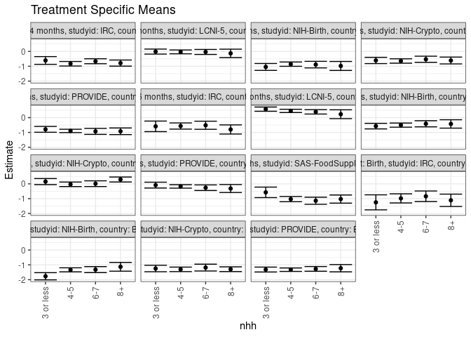

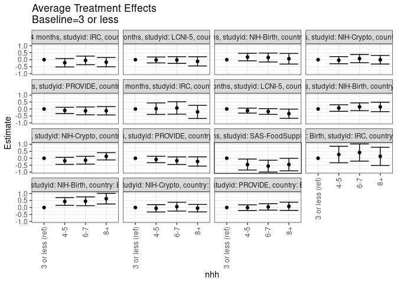

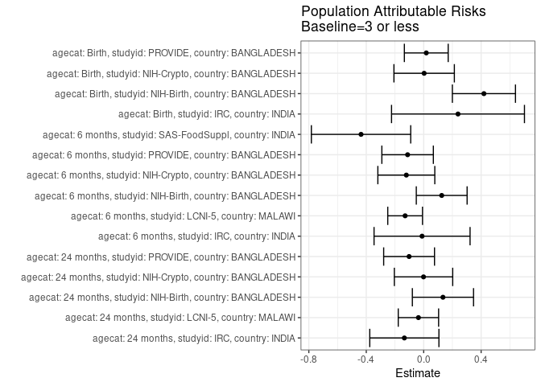

## Results Table

### Parameter: TSM

| agecat | studyid | country | intervention_level | baseline_level | estimate | ci_lower | ci_upper |
| --- | --- | --- | --- | --- | --- | --- | --- |
| Birth | IRC | INDIA | 3 or less | NA | -1.2495106 | -1.7558541 | -0.7431670 |
| Birth | IRC | INDIA | 4-5 | NA | -0.9822783 | -1.2903816 | -0.6741749 |
| Birth | IRC | INDIA | 6-7 | NA | -0.8393378 | -1.1955930 | -0.4830826 |
| Birth | IRC | INDIA | 8+ | NA | -1.1119259 | -1.5278852 | -0.6959666 |
| Birth | NIH-Birth | BANGLADESH | 3 or less | NA | -1.7693917 | -2.0113425 | -1.5274408 |
| Birth | NIH-Birth | BANGLADESH | 4-5 | NA | -1.3354292 | -1.4721055 | -1.1987528 |
| Birth | NIH-Birth | BANGLADESH | 6-7 | NA | -1.3208016 | -1.5230498 | -1.1185535 |
| Birth | NIH-Birth | BANGLADESH | 8+ | NA | -1.1322759 | -1.4267530 | -0.8377988 |
| Birth | NIH-Crypto | BANGLADESH | 3 or less | NA | -1.2472770 | -1.4650925 | -1.0294614 |
| Birth | NIH-Crypto | BANGLADESH | 4-5 | NA | -1.3039707 | -1.4552325 | -1.1527088 |
| Birth | NIH-Crypto | BANGLADESH | 6-7 | NA | -1.1843948 | -1.4142720 | -0.9545176 |
| Birth | NIH-Crypto | BANGLADESH | 8+ | NA | -1.2936304 | -1.4527330 | -1.1345278 |
| Birth | PROVIDE | BANGLADESH | 3 or less | NA | -1.3164415 | -1.4819079 | -1.1509750 |
| Birth | PROVIDE | BANGLADESH | 4-5 | NA | -1.3260393 | -1.4424432 | -1.2096354 |
| Birth | PROVIDE | BANGLADESH | 6-7 | NA | -1.2726432 | -1.4307503 | -1.1145362 |
| Birth | PROVIDE | BANGLADESH | 8+ | NA | -1.2267042 | -1.4721657 | -0.9812427 |
| 6 months | IRC | INDIA | 3 or less | NA | -0.5875265 | -0.9435024 | -0.2315507 |
| 6 months | IRC | INDIA | 4-5 | NA | -0.5667645 | -0.7748497 | -0.3586793 |
| 6 months | IRC | INDIA | 6-7 | NA | -0.5151279 | -0.7880413 | -0.2422145 |
| 6 months | IRC | INDIA | 8+ | NA | -0.7981219 | -1.1060920 | -0.4901519 |
| 6 months | LCNI-5 | MALAWI | 3 or less | NA | 0.5711047 | 0.4291746 | 0.7130348 |
| 6 months | LCNI-5 | MALAWI | 4-5 | NA | 0.4536273 | 0.3435223 | 0.5637322 |
| 6 months | LCNI-5 | MALAWI | 6-7 | NA | 0.3895251 | 0.2403819 | 0.5386683 |
| 6 months | LCNI-5 | MALAWI | 8+ | NA | 0.2306725 | -0.0670366 | 0.5283817 |
| 6 months | NIH-Birth | BANGLADESH | 3 or less | NA | -0.5728420 | -0.7608115 | -0.3848726 |
| 6 months | NIH-Birth | BANGLADESH | 4-5 | NA | -0.5064846 | -0.6462395 | -0.3667297 |
| 6 months | NIH-Birth | BANGLADESH | 6-7 | NA | -0.4153042 | -0.6218886 | -0.2087197 |
| 6 months | NIH-Birth | BANGLADESH | 8+ | NA | -0.4255358 | -0.7081040 | -0.1429676 |
| 6 months | NIH-Crypto | BANGLADESH | 3 or less | NA | 0.1506824 | -0.0526391 | 0.3540039 |
| 6 months | NIH-Crypto | BANGLADESH | 4-5 | NA | -0.0332231 | -0.1856279 | 0.1191816 |
| 6 months | NIH-Crypto | BANGLADESH | 6-7 | NA | 0.0080175 | -0.1842972 | 0.2003322 |
| 6 months | NIH-Crypto | BANGLADESH | 8+ | NA | 0.2914288 | 0.1242555 | 0.4586021 |
| 6 months | PROVIDE | BANGLADESH | 3 or less | NA | -0.0870782 | -0.2831503 | 0.1089939 |
| 6 months | PROVIDE | BANGLADESH | 4-5 | NA | -0.1748153 | -0.2908314 | -0.0587993 |
| 6 months | PROVIDE | BANGLADESH | 6-7 | NA | -0.2624294 | -0.4505492 | -0.0743096 |
| 6 months | PROVIDE | BANGLADESH | 8+ | NA | -0.3185620 | -0.5880067 | -0.0491173 |
| 6 months | SAS-FoodSuppl | INDIA | 3 or less | NA | -0.5758507 | -0.9291334 | -0.2225681 |
| 6 months | SAS-FoodSuppl | INDIA | 4-5 | NA | -1.0296404 | -1.2061965 | -0.8530842 |
| 6 months | SAS-FoodSuppl | INDIA | 6-7 | NA | -1.1408767 | -1.3796978 | -0.9020557 |
| 6 months | SAS-FoodSuppl | INDIA | 8+ | NA | -1.0279683 | -1.3029567 | -0.7529799 |
| 24 months | IRC | INDIA | 3 or less | NA | -0.6110843 | -0.8716323 | -0.3505363 |
| 24 months | IRC | INDIA | 4-5 | NA | -0.8308229 | -0.9838986 | -0.6777471 |
| 24 months | IRC | INDIA | 6-7 | NA | -0.6630965 | -0.8305536 | -0.4956395 |
| 24 months | IRC | INDIA | 8+ | NA | -0.7870996 | -0.9928198 | -0.5813793 |
| 24 months | LCNI-5 | MALAWI | 3 or less | NA | -0.0111575 | -0.1802426 | 0.1579277 |
| 24 months | LCNI-5 | MALAWI | 4-5 | NA | -0.0308210 | -0.1601747 | 0.0985328 |
| 24 months | LCNI-5 | MALAWI | 6-7 | NA | -0.0355936 | -0.2039033 | 0.1327161 |
| 24 months | LCNI-5 | MALAWI | 8+ | NA | -0.1311509 | -0.4146950 | 0.1523931 |
| 24 months | NIH-Birth | BANGLADESH | 3 or less | NA | -1.0456967 | -1.2775886 | -0.8138048 |
| 24 months | NIH-Birth | BANGLADESH | 4-5 | NA | -0.8579910 | -1.0027580 | -0.7132240 |
| 24 months | NIH-Birth | BANGLADESH | 6-7 | NA | -0.8896840 | -1.1105908 | -0.6687773 |
| 24 months | NIH-Birth | BANGLADESH | 8+ | NA | -0.9798289 | -1.2833451 | -0.6763128 |
| 24 months | NIH-Crypto | BANGLADESH | 3 or less | NA | -0.6092209 | -0.8194975 | -0.3989443 |
| 24 months | NIH-Crypto | BANGLADESH | 4-5 | NA | -0.6460531 | -0.7931980 | -0.4989082 |
| 24 months | NIH-Crypto | BANGLADESH | 6-7 | NA | -0.5292946 | -0.7365197 | -0.3220694 |
| 24 months | NIH-Crypto | BANGLADESH | 8+ | NA | -0.6117991 | -0.8416653 | -0.3819330 |
| 24 months | PROVIDE | BANGLADESH | 3 or less | NA | -0.7911550 | -0.9870813 | -0.5952287 |
| 24 months | PROVIDE | BANGLADESH | 4-5 | NA | -0.8968305 | -1.0096239 | -0.7840371 |
| 24 months | PROVIDE | BANGLADESH | 6-7 | NA | -0.9274306 | -1.1304813 | -0.7243799 |
| 24 months | PROVIDE | BANGLADESH | 8+ | NA | -0.9214922 | -1.1452596 | -0.6977248 |

### Parameter: E(Y)

| agecat | studyid | country | intervention_level | baseline_level | estimate | ci_lower | ci_upper |
| --- | --- | --- | --- | --- | --- | --- | --- |
| Birth | IRC | INDIA | NA | NA | -1.0105831 | -1.1973019 | -0.8238643 |
| Birth | NIH-Birth | BANGLADESH | NA | NA | -1.3499217 | -1.4444634 | -1.2553801 |
| Birth | NIH-Crypto | BANGLADESH | NA | NA | -1.2441513 | -1.3281130 | -1.1601897 |
| Birth | PROVIDE | BANGLADESH | NA | NA | -1.2984586 | -1.3752758 | -1.2216415 |
| 6 months | IRC | INDIA | NA | NA | -0.5989297 | -0.7344491 | -0.4634104 |
| 6 months | LCNI-5 | MALAWI | NA | NA | 0.4417647 | 0.3702742 | 0.5132552 |
| 6 months | NIH-Birth | BANGLADESH | NA | NA | -0.4474038 | -0.5378167 | -0.3569909 |
| 6 months | NIH-Crypto | BANGLADESH | NA | NA | 0.0297622 | -0.0491685 | 0.1086930 |
| 6 months | PROVIDE | BANGLADESH | NA | NA | -0.1990907 | -0.2817968 | -0.1163845 |
| 6 months | SAS-FoodSuppl | INDIA | NA | NA | -1.0121579 | -1.1280429 | -0.8962729 |
| 24 months | IRC | INDIA | NA | NA | -0.7458150 | -0.8368180 | -0.6548120 |
| 24 months | LCNI-5 | MALAWI | NA | NA | -0.0477867 | -0.1301103 | 0.0345368 |
| 24 months | NIH-Birth | BANGLADESH | NA | NA | -0.9115790 | -1.0095022 | -0.8136559 |
| 24 months | NIH-Crypto | BANGLADESH | NA | NA | -0.6103502 | -0.7050157 | -0.5156847 |
| 24 months | PROVIDE | BANGLADESH | NA | NA | -0.8928670 | -0.9755153 | -0.8102187 |

### Parameter: ATE

| agecat | studyid | country | intervention_level | baseline_level | estimate | ci_lower | ci_upper |
| --- | --- | --- | --- | --- | --- | --- | --- |
| Birth | IRC | INDIA | 3 or less | 3 or less | 0.0000000 | 0.0000000 | 0.0000000 |
| Birth | IRC | INDIA | 4-5 | 3 or less | 0.2672323 | -0.3237742 | 0.8582388 |
| Birth | IRC | INDIA | 6-7 | 3 or less | 0.4101728 | -0.2081173 | 1.0284629 |
| Birth | IRC | INDIA | 8+ | 3 or less | 0.1375847 | -0.5170596 | 0.7922289 |
| Birth | NIH-Birth | BANGLADESH | 3 or less | 3 or less | 0.0000000 | 0.0000000 | 0.0000000 |
| Birth | NIH-Birth | BANGLADESH | 4-5 | 3 or less | 0.4339625 | 0.1556461 | 0.7122790 |
| Birth | NIH-Birth | BANGLADESH | 6-7 | 3 or less | 0.4485900 | 0.1323693 | 0.7648108 |
| Birth | NIH-Birth | BANGLADESH | 8+ | 3 or less | 0.6371158 | 0.2553967 | 1.0188349 |
| Birth | NIH-Crypto | BANGLADESH | 3 or less | 3 or less | 0.0000000 | 0.0000000 | 0.0000000 |
| Birth | NIH-Crypto | BANGLADESH | 4-5 | 3 or less | -0.0566937 | -0.3210982 | 0.2077108 |
| Birth | NIH-Crypto | BANGLADESH | 6-7 | 3 or less | 0.0628821 | -0.2534362 | 0.3792005 |
| Birth | NIH-Crypto | BANGLADESH | 8+ | 3 or less | -0.0463534 | -0.3151603 | 0.2224535 |
| Birth | PROVIDE | BANGLADESH | 3 or less | 3 or less | 0.0000000 | 0.0000000 | 0.0000000 |
| Birth | PROVIDE | BANGLADESH | 4-5 | 3 or less | -0.0095979 | -0.2120624 | 0.1928666 |
| Birth | PROVIDE | BANGLADESH | 6-7 | 3 or less | 0.0437982 | -0.1850570 | 0.2726534 |
| Birth | PROVIDE | BANGLADESH | 8+ | 3 or less | 0.0897373 | -0.2062790 | 0.3857535 |
| 6 months | IRC | INDIA | 3 or less | 3 or less | 0.0000000 | 0.0000000 | 0.0000000 |
| 6 months | IRC | INDIA | 4-5 | 3 or less | 0.0207621 | -0.3919195 | 0.4334436 |
| 6 months | IRC | INDIA | 6-7 | 3 or less | 0.0723986 | -0.3762518 | 0.5210491 |
| 6 months | IRC | INDIA | 8+ | 3 or less | -0.2105954 | -0.6817730 | 0.2605822 |
| 6 months | LCNI-5 | MALAWI | 3 or less | 3 or less | 0.0000000 | 0.0000000 | 0.0000000 |
| 6 months | LCNI-5 | MALAWI | 4-5 | 3 or less | -0.1174774 | -0.2969822 | 0.0620273 |
| 6 months | LCNI-5 | MALAWI | 6-7 | 3 or less | -0.1815796 | -0.3874956 | 0.0243364 |
| 6 months | LCNI-5 | MALAWI | 8+ | 3 or less | -0.3404322 | -0.6702542 | -0.0106101 |
| 6 months | NIH-Birth | BANGLADESH | 3 or less | 3 or less | 0.0000000 | 0.0000000 | 0.0000000 |
| 6 months | NIH-Birth | BANGLADESH | 4-5 | 3 or less | 0.0663574 | -0.1681249 | 0.3008398 |
| 6 months | NIH-Birth | BANGLADESH | 6-7 | 3 or less | 0.1575379 | -0.1213424 | 0.4364181 |
| 6 months | NIH-Birth | BANGLADESH | 8+ | 3 or less | 0.1473062 | -0.1913181 | 0.4859305 |
| 6 months | NIH-Crypto | BANGLADESH | 3 or less | 3 or less | 0.0000000 | 0.0000000 | 0.0000000 |
| 6 months | NIH-Crypto | BANGLADESH | 4-5 | 3 or less | -0.1839055 | -0.4380762 | 0.0702652 |
| 6 months | NIH-Crypto | BANGLADESH | 6-7 | 3 or less | -0.1426649 | -0.4224823 | 0.1371526 |
| 6 months | NIH-Crypto | BANGLADESH | 8+ | 3 or less | 0.1407465 | -0.1228951 | 0.4043881 |
| 6 months | PROVIDE | BANGLADESH | 3 or less | 3 or less | 0.0000000 | 0.0000000 | 0.0000000 |
| 6 months | PROVIDE | BANGLADESH | 4-5 | 3 or less | -0.0877371 | -0.3157723 | 0.1402980 |
| 6 months | PROVIDE | BANGLADESH | 6-7 | 3 or less | -0.1753512 | -0.4472059 | 0.0965034 |
| 6 months | PROVIDE | BANGLADESH | 8+ | 3 or less | -0.2314838 | -0.5648872 | 0.1019195 |
| 6 months | SAS-FoodSuppl | INDIA | 3 or less | 3 or less | 0.0000000 | 0.0000000 | 0.0000000 |
| 6 months | SAS-FoodSuppl | INDIA | 4-5 | 3 or less | -0.4537897 | -0.8486203 | -0.0589591 |
| 6 months | SAS-FoodSuppl | INDIA | 6-7 | 3 or less | -0.5650260 | -0.9919010 | -0.1381511 |
| 6 months | SAS-FoodSuppl | INDIA | 8+ | 3 or less | -0.4521176 | -0.8991853 | -0.0050499 |
| 24 months | IRC | INDIA | 3 or less | 3 or less | 0.0000000 | 0.0000000 | 0.0000000 |
| 24 months | IRC | INDIA | 4-5 | 3 or less | -0.2197385 | -0.5219493 | 0.0824723 |
| 24 months | IRC | INDIA | 6-7 | 3 or less | -0.0520122 | -0.3617451 | 0.2577206 |
| 24 months | IRC | INDIA | 8+ | 3 or less | -0.1760153 | -0.5082097 | 0.1561792 |
| 24 months | LCNI-5 | MALAWI | 3 or less | 3 or less | 0.0000000 | 0.0000000 | 0.0000000 |
| 24 months | LCNI-5 | MALAWI | 4-5 | 3 or less | -0.0196635 | -0.2321176 | 0.1927907 |
| 24 months | LCNI-5 | MALAWI | 6-7 | 3 or less | -0.0244361 | -0.2627077 | 0.2138355 |
| 24 months | LCNI-5 | MALAWI | 8+ | 3 or less | -0.1199934 | -0.4501563 | 0.2101694 |
| 24 months | NIH-Birth | BANGLADESH | 3 or less | 3 or less | 0.0000000 | 0.0000000 | 0.0000000 |
| 24 months | NIH-Birth | BANGLADESH | 4-5 | 3 or less | 0.1877057 | -0.0820491 | 0.4574605 |
| 24 months | NIH-Birth | BANGLADESH | 6-7 | 3 or less | 0.1560127 | -0.1625620 | 0.4745873 |
| 24 months | NIH-Birth | BANGLADESH | 8+ | 3 or less | 0.0658678 | -0.3146640 | 0.4463996 |
| 24 months | NIH-Crypto | BANGLADESH | 3 or less | 3 or less | 0.0000000 | 0.0000000 | 0.0000000 |
| 24 months | NIH-Crypto | BANGLADESH | 4-5 | 3 or less | -0.0368322 | -0.2932325 | 0.2195681 |
| 24 months | NIH-Crypto | BANGLADESH | 6-7 | 3 or less | 0.0799263 | -0.2150248 | 0.3748774 |
| 24 months | NIH-Crypto | BANGLADESH | 8+ | 3 or less | -0.0025782 | -0.3139231 | 0.3087666 |
| 24 months | PROVIDE | BANGLADESH | 3 or less | 3 or less | 0.0000000 | 0.0000000 | 0.0000000 |
| 24 months | PROVIDE | BANGLADESH | 4-5 | 3 or less | -0.1056755 | -0.3299990 | 0.1186480 |
| 24 months | PROVIDE | BANGLADESH | 6-7 | 3 or less | -0.1362756 | -0.4170862 | 0.1445351 |
| 24 months | PROVIDE | BANGLADESH | 8+ | 3 or less | -0.1303372 | -0.4274296 | 0.1667552 |

### Parameter: PAR

| agecat | studyid | country | intervention_level | baseline_level | estimate | ci_lower | ci_upper |
| --- | --- | --- | --- | --- | --- | --- | --- |
| Birth | IRC | INDIA | 3 or less | NA | 0.2389275 | -0.2239585 | 0.7018134 |
| Birth | NIH-Birth | BANGLADESH | 3 or less | NA | 0.4194699 | 0.1997076 | 0.6392323 |
| Birth | NIH-Crypto | BANGLADESH | 3 or less | NA | 0.0031256 | -0.2072861 | 0.2135373 |
| Birth | PROVIDE | BANGLADESH | 3 or less | NA | 0.0179828 | -0.1346127 | 0.1705783 |
| 6 months | IRC | INDIA | 3 or less | NA | -0.0114032 | -0.3457454 | 0.3229390 |
| 6 months | LCNI-5 | MALAWI | 3 or less | NA | -0.1293400 | -0.2502900 | -0.0083900 |
| 6 months | NIH-Birth | BANGLADESH | 3 or less | NA | 0.1254383 | -0.0515355 | 0.3024120 |
| 6 months | NIH-Crypto | BANGLADESH | 3 or less | NA | -0.1209201 | -0.3192314 | 0.0773912 |
| 6 months | PROVIDE | BANGLADESH | 3 or less | NA | -0.1120125 | -0.2913378 | 0.0673129 |
| 6 months | SAS-FoodSuppl | INDIA | 3 or less | NA | -0.4363072 | -0.7822762 | -0.0903381 |
| 24 months | IRC | INDIA | 3 or less | NA | -0.1347307 | -0.3755315 | 0.1060702 |
| 24 months | LCNI-5 | MALAWI | 3 or less | NA | -0.0366293 | -0.1771683 | 0.1039098 |
| 24 months | NIH-Birth | BANGLADESH | 3 or less | NA | 0.1341177 | -0.0789655 | 0.3472008 |
| 24 months | NIH-Crypto | BANGLADESH | 3 or less | NA | -0.0011293 | -0.2043419 | 0.2020833 |
| 24 months | PROVIDE | BANGLADESH | 3 or less | NA | -0.1017120 | -0.2787378 | 0.0753138 |